# Session 2 Workbook — A Real Analysis in R

MSc Epidemiology · Intro to R & SAS

Your name here

17 September 2026

# How to use this workbook

Open this file in RStudio **inside the seminar RStudio Project**, so that the `data/` folder sits beside it. Then:

- Run one chunk at a time with the green ▶ button, or `Ctrl`/`Cmd` + `Shift` + `Enter`
- Work through the `## YOUR TURN` chunks — they are deliberately incomplete
- **Knit** the whole thing at the end (the Knit button) to prove it runs top to bottom

If knitting fails but the chunks all ran, you have an ordering problem: something later depends on an object you created out of sequence. That is exactly the bug that reproducibility checks are meant to catch, and it is worth fixing.

```r
# install.packages(c("tidyverse", "broom", "janitor", "gtsummary"))  # once, if needed
library(tidyverse)
library(broom)
```

# 1 · Import and first look

```r
births    <- read_csv("data/births.csv",    show_col_types = FALSE)
mothers   <- read_csv("data/mothers.csv",   show_col_types = FALSE)
screening <- read_csv("data/screening.csv", show_col_types = FALSE)

dim(births); dim(mothers); dim(screening)
```

```
## [1] 1239    9
```

```
## [1] 1200    7
```

```
## [1] 1338    9
```

```r
glimpse(births)
```

```
## Rows: 1,239
## Columns: 9
## $ infant_id      <chr> "B-0001", "B-0002", "B-0003", "B-0004", "B-0005", "B-00~
## $ momid          <chr> "M-0001", "M-0001", "M-0002", "M-0003", "M-0004", "M-00~
## $ birth_datetime <dttm> 2025-11-28 09:37:00, 2025-11-28 09:41:00, 2025-12-17 0~
## $ ga_weeks       <dbl> 35.74, 37.65, 39.86, 39.76, 37.59, 39.97, 39.66, 36.80,~
## $ birth_weight_g <dbl> 1792, 2621, 4116, 3255, 3325, 3776, 3498, 3401, 4082, 3~
## $ sex            <chr> "F", "m", "F", "M", "M", "F", "F", "M", "M", "F", "F", ~
## $ multiple       <dbl> 1, 1, 0, 0, 0, 0, 0, 0, 0, 0, 0, 0, 0, 0, 0, 0, 0, 0, 0~
## $ delivery_mode  <chr> "caesarean", "caesarean", "vaginal", "caesarean", "caes~
## $ site           <chr> "Toronto", "Kingston", "Toronto", "Ottawa", "Thunder Ba~
```

Three things are already wrong with this data. Find them:

```r
count(births, sex)                  # 1. ?
```

| sex | n |
| --- | --- |
| F | 585 |
| M | 628 |
| f | 11 |
| m | 15 |

```r
colSums(is.na(mothers))             # 2. ?
```

```
##        momid      mat_age       parity      mat_bmi      smoking diabetes_pre
##            0            0            0           60            0            0
## hypertension
##            0
```

```r
c(rows = nrow(screening), infants = n_distinct(screening$infant_id))   # 3. ?
```

```
##    rows infants
##    1338    1205
```

> **1.** `sex` is coded four ways (`F`, `M`, `f`, `m`). **2.** `mat_bmi` has missing values. **3.** Some infants have more than one screening specimen.

## YOUR TURN

How many births are preterm (`ga_weeks < 37`), and what percentage is that?

```r
# sum(...)
# 100 * mean(...)
```

# 2 · Clean and derive

```r
births_clean <- births |>
  mutate(
    sex      = toupper(sex),
    bw_kg    = birth_weight_g / 1000,
    preterm  = ga_weeks < 37,
    ga_group = factor(
      case_when(
        ga_weeks < 32 ~ "very preterm",
        ga_weeks < 37 ~ "preterm",
        ga_weeks < 42 ~ "term",
        .default      = "post-term"
      ),
      levels = c("term", "preterm", "very preterm", "post-term")
    )
  )

count(births_clean, ga_group)
```

| ga_group | n |
| --- | --- |
| term | 1093 |
| preterm | 119 |
| very preterm | 24 |
| post-term | 3 |

```r
count(births_clean, sex)
```

| sex | n |
| --- | --- |
| F | 596 |
| M | 643 |

`janitor::clean_names()` does the equivalent tidying for *variable names* — useful when data arrives from Excel with names like `Birth Weight (g)`:

```r
births |> janitor::clean_names() |> names()
```

## YOUR TURN

Create `bw_cat` with levels `very low` (<1500 g), `low` (<2500 g) and `normal`, then cross-tabulate it against `ga_group`.

```r
# births_clean |>
#   mutate(bw_cat = case_when(...)) |>
#   count(ga_group, bw_cat)
```

# 3 · The join that ruins analyses

This is the single most important section of the workshop.

```r
naive <- left_join(births_clean, screening, by = "infant_id")

c(births = nrow(births_clean), naive_join = nrow(naive))
```

```
##     births naive_join
##       1239       1372
```

The row count changed. Find out why:

```r
naive |> count(infant_id) |> filter(n > 1) |> nrow()
```

```
## [1] 133
```

Now do it properly — one screening record per infant:

```r
first_spec <- screening |> filter(specimen_no == 1)

analysis <- births_clean |>
  left_join(first_spec, by = "infant_id") |>
  left_join(mothers,    by = "momid")

stopifnot(nrow(analysis) == nrow(births_clean))   # fail loudly if not
nrow(analysis)
```

```
## [1] 1239
```

`stopifnot()` is a **guard rail**. Put one after every join. If a future version of the data breaks your assumption, the script stops instead of quietly producing a different answer.

Audit who didn’t link:

```r
unscreened <- anti_join(births_clean, screening, by = "infant_id")
nrow(unscreened)
```

```
## [1] 34
```

```r
bind_rows(
  unscreened |> mutate(grp = "no screen"),
  semi_join(births_clean, screening, by = "infant_id") |> mutate(grp = "screened")
) |>
  group_by(grp) |>
  summarise(n = n(),
            mean_ga = mean(ga_weeks),
            mean_bw = mean(birth_weight_g),
            .groups = "drop")
```

| grp | n | mean_ga | mean_bw |
| --- | --- | --- | --- |
| no screen | 34 | 38.69294 | 3295.588 |
| screened | 1205 | 38.63583 | 3312.514 |

## YOUR TURN

Are the unscreened infants different in a way that would bias a complete-case analysis? Write one or two sentences below, as you would in a Limitations paragraph.

> *Your answer here.*

# 4 · Summarise

```r
analysis |>
  group_by(site, sex) |>
  summarise(
    n           = n(),
    mean_bw     = mean(birth_weight_g),
    sd_bw       = sd(birth_weight_g),
    pct_preterm = 100 * mean(preterm),
    .groups     = "drop"
  ) |>
  arrange(desc(n))
```

| site | sex | n | mean_bw | sd_bw | pct_preterm |
| --- | --- | --- | --- | --- | --- |
| Ottawa | M | 257 | 3372.412 | 594.7100 | 12.062257 |
| Ottawa | F | 211 | 3197.057 | 480.7466 | 13.270142 |
| Toronto | F | 163 | 3249.847 | 502.0901 | 14.723926 |
| Toronto | M | 161 | 3343.795 | 565.9343 | 12.422360 |
| Kingston | M | 95 | 3416.411 | 685.1202 | 12.631579 |
| Kingston | F | 94 | 3258.000 | 414.2022 | 5.319149 |
| Sudbury | M | 72 | 3441.111 | 596.0544 | 9.722222 |
| Sudbury | F | 70 | 3253.329 | 542.9290 | 10.000000 |
| Thunder Bay | F | 58 | 3243.414 | 491.1959 | 10.344828 |
| Thunder Bay | M | 58 | 3445.552 | 481.9742 | 5.172414 |

## YOUR TURN

Median and IQR of `x17ohp` by `ga_group`, with the number of non-missing values in each group. Remember `na.rm = TRUE`.

```r
# analysis |>
#   group_by(ga_group) |>
#   summarise(n = sum(!is.na(x17ohp)),
#             median = ...,
#             q1 = quantile(..., 0.25, na.rm = TRUE),
#             q3 = ...)
```

# 5 · Dates

```r
timing <- analysis |>
  mutate(
    birth_date  = as_date(birth_datetime),
    birth_month = month(birth_datetime, label = TRUE),
    hours_to_collection = as.numeric(
      difftime(collection_datetime, birth_datetime, units = "hours")
    )
  )

timing |>
  summarise(
    median_h = median(hours_to_collection, na.rm = TRUE),
    n_before_24h = sum(hours_to_collection < 24, na.rm = TRUE)
  )
```

| median_h | n_before_24h |
| --- | --- |
| 48.1 | 0 |

# 6 · Missing data

```r
analysis |>
  summarise(across(everything(), ~ sum(is.na(.x)))) |>
  pivot_longer(everything(), names_to = "variable", values_to = "n_missing") |>
  filter(n_missing > 0) |>
  arrange(desc(n_missing))
```

| variable | n_missing |
| --- | --- |
| x17ohp | 103 |
| mat_bmi | 62 |
| specimen_no | 34 |
| collection_datetime | 34 |
| age_at_collection_h | 34 |
| tsh | 34 |
| phe | 34 |
| leu | 34 |
| ala | 34 |

`drop_na()` is one keystroke and a substantive assumption (MCAR). For anything going into a manuscript, look at `mice::mice()` for multiple imputation.

# 7 · Table 1

Hand-rolled, so you can see what it is doing:

```r
analysis |>
  mutate(preterm_lab = if_else(preterm, "Preterm (<37 wk)", "Term")) |>
  group_by(preterm_lab) |>
  summarise(
    n             = n(),
    mat_age       = sprintf("%.1f (%.1f)", mean(mat_age), sd(mat_age)),
    mat_bmi       = sprintf("%.1f (%.1f)", mean(mat_bmi, na.rm = TRUE), sd(mat_bmi, na.rm = TRUE)),
    smoking_pct   = sprintf("%.1f", 100 * mean(smoking == "yes")),
    hypertens_pct = sprintf("%.1f", 100 * mean(hypertension)),
    birthwt       = sprintf("%.0f (%.0f)", mean(birth_weight_g), sd(birth_weight_g)),
    .groups = "drop"
  )
```

| preterm_lab | n | mat_age | mat_bmi | smoking_pct | hypertens_pct | birthwt |
| --- | --- | --- | --- | --- | --- | --- |
| Preterm (<37 wk) | 143 | 31.4 (4.8) | 26.2 (5.2) | 17.5 | 5.6 | 2475 (674) |
| Term | 1096 | 30.5 (5.3) | 26.0 (5.1) | 7.9 | 3.7 | 3421 (421) |

And the two-line version you will actually use. `gtsummary` exports cleanly to Word:

```r
library(gtsummary)

analysis |>
  select(preterm, mat_age, mat_bmi, smoking, hypertension, diabetes_pre,
         birth_weight_g, sex, delivery_mode) |>
  tbl_summary(by = preterm, missing_text = "Missing") |>
  add_p() |>
  add_overall() |>
  bold_labels()
```

# 8 · Figures

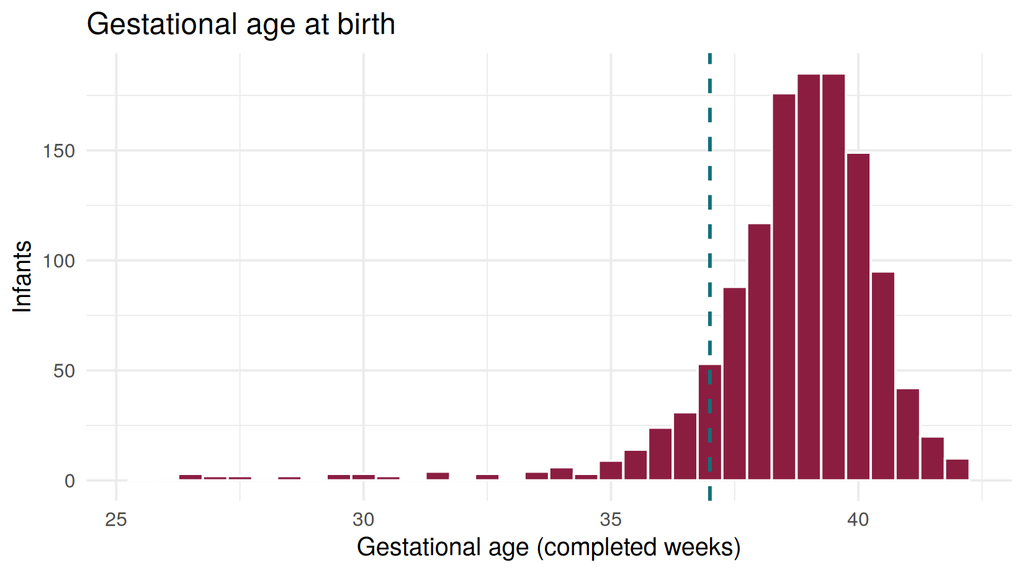

```r
ggplot(analysis, aes(ga_weeks)) +
  geom_histogram(binwidth = 0.5, fill = "#8b1d41", colour = "white") +
  geom_vline(xintercept = 37, linetype = "dashed", colour = "#12707a", linewidth = 0.9) +
  labs(x = "Gestational age (completed weeks)", y = "Infants",
       title = "Gestational age at birth") +
  theme_minimal(base_size = 13)
```

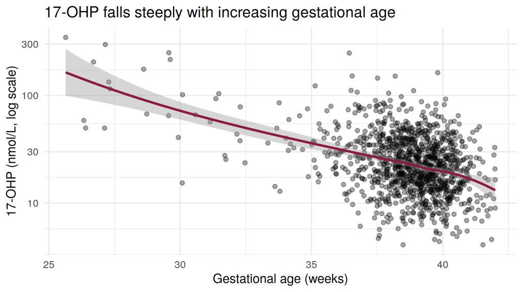

```r
analysis |>
  filter(!is.na(x17ohp)) |>
  ggplot(aes(ga_weeks, x17ohp)) +
  geom_point(alpha = 0.35) +
  geom_smooth(method = "loess", colour = "#8b1d41") +
  scale_y_log10() +
  labs(x = "Gestational age (weeks)", y = "17-OHP (nmol/L, log scale)",
       title = "17-OHP falls steeply with increasing gestational age") +
  theme_minimal(base_size = 13)
```

## YOUR TURN

Birth weight against gestational age, coloured by `sex`, with a linear smooth, faceted by `site`. Give it publication-ready axis labels.

```r
# ggplot(analysis, aes(...)) + ...
```

# 9 · Models

```r
m_bw <- lm(birth_weight_g ~ ga_weeks + sex + smoking + mat_age, data = analysis)
tidy(m_bw, conf.int = TRUE) |> mutate(across(where(is.numeric), \(x) round(x, 2)))
```

| term | estimate | std.error | statistic | p.value | conf.low | conf.high |
| --- | --- | --- | --- | --- | --- | --- |
| (Intercept) | -4495.57 | 219.56 | -20.48 | 0.0 | -4926.32 | -4064.82 |
| ga_weeks | 199.36 | 5.27 | 37.83 | 0.0 | 189.02 | 209.70 |
| sexM | 173.57 | 20.70 | 8.38 | 0.0 | 132.95 | 214.19 |
| smokingyes | -186.58 | 36.23 | -5.15 | 0.0 | -257.65 | -115.51 |
| mat_age | 1.04 | 1.97 | 0.53 | 0.6 | -2.83 | 4.91 |

```r
glance(m_bw) |> select(r.squared, adj.r.squared, sigma, nobs)
```

| r.squared | adj.r.squared | sigma | nobs |
| --- | --- | --- | --- |
| 0.5619964 | 0.5605766 | 363.5554 | 1239 |

```r
m_pt <- glm(preterm ~ mat_age + smoking + hypertension + diabetes_pre,
            data = analysis, family = binomial)
tidy(m_pt, exponentiate = TRUE, conf.int = TRUE) |>
  mutate(across(where(is.numeric), \(x) round(x, 3)))
```

| term | estimate | std.error | statistic | p.value | conf.low | conf.high |
| --- | --- | --- | --- | --- | --- | --- |
| (Intercept) | 0.038 | 0.548 | -5.987 | 0.000 | 0.013 | 0.108 |
| mat_age | 1.034 | 0.017 | 1.948 | 0.051 | 1.000 | 1.070 |
| smokingyes | 2.292 | 0.251 | 3.306 | 0.001 | 1.378 | 3.698 |
| hypertension | 1.459 | 0.407 | 0.929 | 0.353 | 0.613 | 3.077 |
| diabetes_pre | 2.102 | 0.254 | 2.929 | 0.003 | 1.256 | 3.406 |

A forest plot straight from `tidy()` output — this is why `broom` matters:

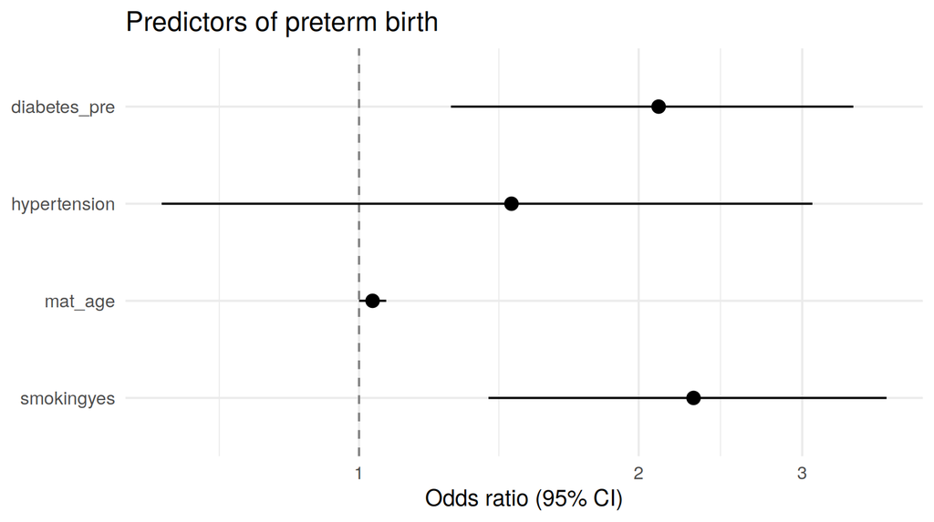

```r
tidy(m_pt, exponentiate = TRUE, conf.int = TRUE) |>
  filter(term != "(Intercept)") |>
  ggplot(aes(estimate, fct_rev(factor(term)))) +
  geom_vline(xintercept = 1, linetype = "dashed", colour = "grey50") +
  geom_pointrange(aes(xmin = conf.low, xmax = conf.high)) +
  scale_x_log10() +
  labs(x = "Odds ratio (95% CI)", y = NULL, title = "Predictors of preterm birth") +
  theme_minimal(base_size = 13)
```

## YOUR TURN — think like an epidemiologist, not a programmer

Twins share a mother, so rows in `analysis` are **not independent**.

1. How many mothers contribute more than one infant?
2. Why does that matter for the standard errors in `m_pt`?
3. What would you do about it?

```r
# analysis |> count(momid) |> filter(n > 1) |> nrow()
```

> *Your answer here.* (Hint: cluster-robust variance, e.g. `sandwich` + `lmtest`, or a random intercept for `momid` with `lme4::glmer()`.)

# 10 · Spot the bugs

An AI assistant produced the code below when asked for “the analysis of preterm birth”. **It runs without error.** There are four things wrong with it. Fix them.

```r
cohort <- births |>
  left_join(screening, by = "infant_id") |>
  left_join(mothers,   by = "momid")

cohort |> summarise(
  n          = n(),
  mean_bw    = mean(birth_weight_g),
  mean_17ohp = mean(x17ohp)
)

count(cohort, sex)

m <- glm(I(ga_weeks < 37) ~ mat_age + smoking + mat_bmi,
         data = cohort, family = gaussian)
tidy(m, exponentiate = TRUE)
```

```r
# Your corrected version here.
```

**Answers (open only after you’ve tried)**

1. The first `left_join()` duplicates infants with a repeat specimen — `nrow()` goes from 1239 to 1372. Filter to `specimen_no == 1` first.
2. `mean(x17ohp)` returns `NA` because 17-OHP has missing values. Needs `na.rm = TRUE` — *and* you should report how many were missing.
3. `sex` is still coded `F`/`M`/`f`/`m`, so any sex-stratified result is wrong.
4. `family = gaussian` on a TRUE/FALSE outcome is a linear probability model; `exponentiate = TRUE` then produces a meaningless number. Use `family = binomial`.
5. (Bonus) Rows are clustered within `momid` because of twins.

Knit this document. If it knits from a clean session, your analysis is reproducible. If it doesn’t, find out why now rather than the week before your defence.